# DHIS2 Analytics Usage Statistics

Sections:

- Visualizations – list totals, bar chart of when created by year/month last 12 months, bar chart of top 20 users creating
- Interpretations – Total+comments, total users, count for top 20 users, visualizations with an interpretation/comment
- Dashboards – Comparison (views, users, visualizations), over time, average views by hour of each day, distinct user-days viewing each dashboard, interpretations left on dashboard objects
- Viz Profile – Views for the image (total views and total users), interpretations+comments

To do:

- Main issue is how to categorize & find the users of interest *at a local level.*
- Should target users all belong to a specific user group, or do they need read access below to a certain OU only? Prefer to put them all in same user group.
- Should visualizations include just those the target users created? Or those they can view in dashboards?
- Messages – Total read and unread, by type, and month over month (TO DO)

Set up and login

```r
# baseurl<-"https://play.dhis2.org/2.37dev/"
# username<-"admin"
# password<-"district"
#
# startdate<-"2015-01-01"
# enddate<-"2021-12-01"

# If set by parameters
baseurl<-params$baseurl
username<-params$username
password<-params$password

startdate<-params$startdate
enddate<-params$enddate


####Load required packages
packages<-c("httr","assertthat","tidyverse","jsonlite","knitr","lubridate","here")
install_or_load_pack <- function(pack){
  create.pkg <- pack[!(pack %in% installed.packages()[, "Package"])]
  if (length(create.pkg))
    install.packages(create.pkg, dependencies = TRUE, quiet=TRUE)
  sapply(pack, require, character.only = TRUE)
}

install_or_load_pack(packages)
```

```
##       httr assertthat  tidyverse   jsonlite      knitr  lubridate       here
##       TRUE       TRUE       TRUE       TRUE       TRUE       TRUE       TRUE
```

```r
# Set theme for charts etc
theme_set(theme_minimal())

# Extract login info from directory
# if (!file.exists("auth.json")){
#   stop("Please add auth.json to directory")
# } else {
#   baseurl<-chuck(fromJSON("auth.json"), "dhis","baseurl")
#   username<-chuck(fromJSON("auth.json"), "dhis","username")
# }


##test login
loginDHIS2<-function(baseurl,username,password){
  url<-paste0(baseurl,"api/me")
  r<-GET(url,authenticate(username,password))
  assert_that(r$status_code == 200L)}

if(loginDHIS2(baseurl,username,password)){
  print("successfully logged in")
}else{
  stop("could not log in! Please check url, username and password in auth.json")
}
```

```
## [1] "successfully logged in"
```

# Visualizations

Extract visualizations and their interpretations

```r
#extract viz types
#might wittle down the fields we want in request, later

fetch_viz_obj<-function(obj_name){

url<-paste0(baseurl,"api/",obj_name,".json?fields=:all&paging=false")

fromJSON(content(GET(url),type="text", encoding="UTF-8")) %>%
  pluck(obj_name) %>%
  select(any_of(c("name","id","createdBy","created", "interpretations","type"))) %>%
  jsonlite::flatten() %>%
  as_tibble() %>%
  complete() %>%
  mutate(int_count = map_int(interpretations, n_distinct),
         obj_name = obj_name) %>%
  select(any_of(c("name","id", "type","int_count","obj_name","created",
                  "createdBy.name","createdBy.id")))

}

# ev_viz<-fetch_viz_obj("eventReports")


viz_list<-list("eventReports","maps","eventCharts","visualizations")

viz_users<-viz_list %>%
    map_dfr(~fetch_viz_obj(.)) %>%
    mutate(type=if_else(is.na(type),toupper(obj_name),type))

#
# viz_users %>%
#   filter(is.na(creator_id) & !is.na(creator_name))


viz_users %>% select(name,type,int_count) %>% slice_sample(n=6) %>%
  kable(caption="A selection of visualizations and their interpretation count")
```

A selection of visualizations and their interpretation count

| name | type | int_count |
| --- | --- | --- |
| HIV: HIV testing by gender | COLUMN | 0 |
| Inpatient: Mode of discharge last 12 months (stacked) | STACKED_COLUMN | 1 |
| Immunization: Measles Cov Facilities this year | MAPS | 0 |
| Immunization: Std dev doses given last 12 months | COLUMN | 0 |
| Commodities: Maternal Health districts last 4 quarters | PIVOT_TABLE | 0 |
| Child Health: Diarrhoea <5 | LINE | 1 |

## Total viz saved and interpretations by viz type

419 visualizations created by 7 users.

“Interpretations” here does not include *user comments* on interpretations.

```r
# viz_users %>%
#   count(type,sort=T)


viz_users %>%
  group_by(type) %>%
  summarize(total_saved=n(),
            total_interpretations=sum(int_count)) %>%
  arrange(-total_saved) %>%
  knitr::kable(caption="Visualizations saved in time window")
```

| type | total_saved | total_interpretations |
| --- | --- | --- |
| PIVOT_TABLE | 130 | 9 |
| COLUMN | 96 | 12 |
| MAPS | 93 | 2 |
| EVENTREPORTS | 31 | 2 |
| LINE | 18 | 5 |
| PIE | 15 | 3 |
| STACKED_COLUMN | 12 | 1 |
| GAUGE | 6 | 0 |
| BAR | 4 | 2 |
| RADAR | 3 | 0 |
| AREA | 2 | 0 |
| SCATTER | 2 | 0 |
| STACKED_BAR | 2 | 0 |
| YEAR_OVER_YEAR_LINE | 2 | 0 |
| SINGLE_VALUE | 1 | 0 |
| STACKED_AREA | 1 | 0 |
| YEAR_OVER_YEAR_COLUMN | 1 | 0 |

“Viz” include event charts, event reports, pivot tables, and maps.

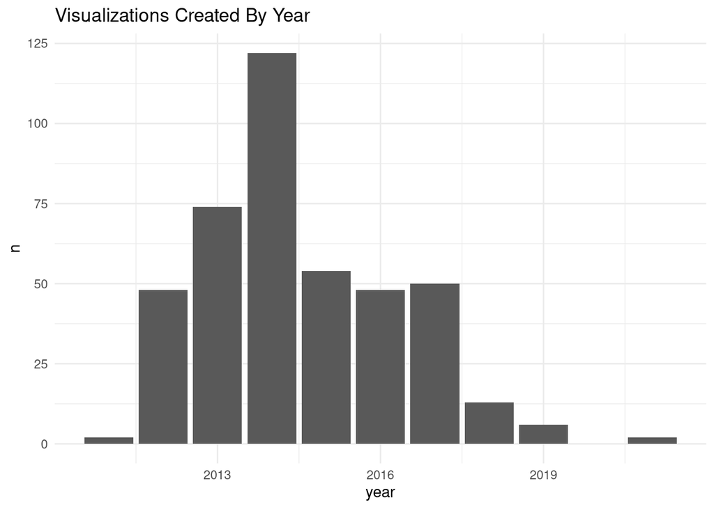

```r
viz_users %>%
  mutate(year=year(created)) %>%
  count(year) %>%
  complete(year=seq(min(year),max(year)), fill=list(n=0)) %>%
  ggplot(aes(x=year,y=n)) +
  geom_col() +
  labs(title="Visualizations Created By Year")
```

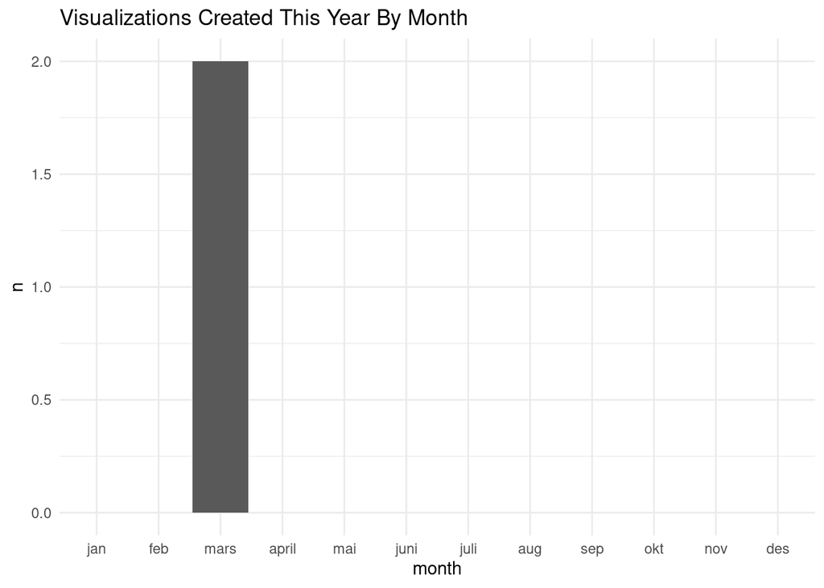

```r
viz_users %>%
    mutate(month=month(created,label=TRUE),
           year=year(created)) %>%
    filter(year==year(Sys.Date())) %>%
    count(month) %>%
    complete(month, fill=list(n=0)) %>%
    ggplot(aes(x=month,y=n)) +
    geom_col() +
    labs(title="Visualizations Created This Year By Month")
```

Top 10 users creating visualizations

```r
viz_users %>%
  count(createdBy.name, sort=T) %>%
  head(10) %>%
  kable(caption="Total visualizations created, top 10 users")
```

Total visualizations created, top 10 users

| createdBy.name | n |
| --- | --- |
| Tom Wakiki | 343 |
| John Traore | 47 |
| NA | 21 |
| Didier Konan | 5 |
| Ali Nana | 1 |
| John Kamara | 1 |
| Kevin Boateng | 1 |

# Dashboards

Extract objects within dashboards

```r
#Get a list of all objects in dashboards
url<-paste0(baseurl,"api/dashboards.json?fields=name,id,dashboardItems&paging=false")
dash<-fromJSON(content(GET(url),type="text", encoding="UTF-8"))

dash_stats<-dash %>%
  pluck("dashboards") %>%
  unnest_longer(dashboardItems) %>%
  jsonlite::flatten() %>%
  as_tibble() %>%
  complete() %>%
  select("dash_name"=name,"dash_id"=id, dashboardItems.created,dashboardItems.lastUpdated,
         dashboardItems.eventChart.id, dashboardItems.eventReport.id,
         dashboardItems.map.id, dashboardItems.visualization.id) %>%
  unite(col="dashItem_viz_id",dashboardItems.visualization.id:dashboardItems.eventReport.id, na.rm=T)

# we can also measure if a dashboard object has been updated or created recently

# dash_stats  %>%
#   mutate(updated=if_else(ymd_hms(dashboardItems.created)==ymd_hms(dashboardItems.lastUpdated), 0, 1)) %>% View()
#   count(updated)

viz_users_dash<-left_join(viz_users,dash_stats %>% select(dash_name,dash_id,dashItem_viz_id),
                          by=c("id"="dashItem_viz_id"))

#Now we can see which dashboards each viz is a part of (considering dashboards the login user can access)
viz_users_dash_merged<-viz_users_dash %>%
        complete() %>%
        group_by(across(.cols=name:int_count)) %>%
        mutate(dash=if_else(is.na(dash_name),0,1)) %>%
        summarize(dash_count=sum(dash),
                  dash_list=paste(dash_name,collapse=" | ")) %>%
        ungroup()
```

## Dashboard Views

```r
#post the datastatisticsevent sql view and fetch data

view_name<-"dataStatisticEvent_"
view_id<-"R6iWYMIDiUt"

sqlView<-list(
  sqlViews=list(
    list(name= view_name,
      id= view_id,
      sqlQuery= "select * from datastatisticsevent",
      type= "MATERIALIZED_VIEW",
      cacheStrategy= "NO_CACHE"
)))


payload<-jsonlite::toJSON(sqlView, auto_unbox = TRUE, pretty=TRUE)

url<-paste0(baseurl,"api/metadata.json")

r<-POST(url, body=payload, content_type_json())
#check
# content(r)

## Update sharing settings
url<-paste0(baseurl,"api/sharing?type=sqlView&id=",view_id)

view_sharing<-list(object=
                list(publicAccess="rwr------",
                  externalAccess=FALSE,
                  user=list(),
                  userGroupAccesses=list()
                )     )

r<-POST(url, body=payload, content_type_json())
#check
#content(r)

#Execute it
url<-paste0(baseurl,"api/sqlViews/",view_id,"/execute")
r<-POST(url)

#finally extract datastat event table between dates
url<-paste0(baseurl,"api/sqlViews/",view_id,"/data.csv?filter=timestamp:ge:",startdate,"&filter=timestamp:le:",enddate)

r<-httr::GET(url, httr::authenticate(username,password),httr::timeout(60))
output<-content(r)
views_dta<-read_csv(output)


# views_dta %>%
#   filter(!is.na(favoriteuid)) %>%
#   left_join(viz_users_dash %>% select(dash_name,dash_id), by=c("favoriteuid"="dash_id")) %>%
#   left_join(viz_users_dash,  by=c("favoriteuid"="dash_id"))

# interpretations

# views_dta
```

Now analyze the dashboard view data

```r
dashboards<-dash_stats %>%
  filter(!is.na(dashItem_viz_id)) %>%
  count(dash_id, dash_name, na.rm=T, name="dash_viz_objects") %>%
  select(dash_id, dash_name, dash_viz_objects) %>%
  na.omit() %>%
  distinct()

dash_views<-views_dta %>%
  filter(str_detect(eventtype,"DASH") & !is.na(favoriteuid)) %>%
  left_join(dashboards, by=c("favoriteuid"="dash_id")) %>%
  mutate(dash_name=if_else(is.na(dash_name),paste0("unnamed_uid_",favoriteuid),dash_name)) %>%
  mutate(date=as.Date(ymd_hms((timestamp))),
         day=wday(date, label=TRUE, abbr=FALSE))
```

In total, there are 342 dashboard views across 27 existing dashboards, by 4 users.

```r
dash_views %>%
  mutate(timestamp=as.Date(timestamp)) %>%
  group_by(dash_name, dash_viz_objects) %>%
  summarize(views=n(),
            distinct_users=n_distinct(username,na.rm=T),
            days_viewed=n_distinct(timestamp,na.rm=T),
            distinct_user_days=n_distinct(paste0(username,timestamp))) %>%
  kable(caption="Comparison of dashboards by user views")
```

Comparison of dashboards by user views

| dash_name | dash_viz_objects | views | distinct_users | days_viewed | distinct_user_days |
| --- | --- | --- | --- | --- | --- |
| Antenatal Care | 11 | 95 | 4 | 29 | 35 |
| Cases Malaria | 8 | 22 | 2 | 13 | 16 |
| Delivery | 11 | 17 | 2 | 10 | 12 |
| Disease Surveillance | 4 | 10 | 2 | 6 | 7 |
| EE maps | 5 | 26 | 2 | 9 | 10 |
| Immunization | 17 | 23 | 2 | 13 | 16 |
| Immunization data | 10 | 15 | 2 | 11 | 12 |
| Info Videos | 5 | 15 | 2 | 6 | 6 |
| Inpatient BMI, Weight and Height | 8 | 11 | 2 | 7 | 8 |
| Inpatient Discharge | 9 | 13 | 2 | 7 | 8 |
| Inpatient Morbidity Mortality | 14 | 15 | 2 | 9 | 9 |
| Inpatient Visit Overview | 3 | 10 | 2 | 5 | 5 |
| Key Indicators | 6 | 8 | 2 | 4 | 4 |
| Malnutrition | 7 | 2 | 1 | 1 | 1 |
| Measles (user org unit) | 6 | 4 | 2 | 3 | 3 |
| Mother and Child Health | 17 | 3 | 1 | 1 | 1 |
| Nutrition | 6 | 3 | 2 | 3 | 3 |
| Reporting Rates | 8 | 6 | 1 | 2 | 2 |
| Reporting Reproductive Health | 11 | 9 | 2 | 4 | 4 |
| Staffing | 2 | 6 | 2 | 3 | 3 |
| Top Contacts | 3 | 6 | 2 | 4 | 4 |
| unnamed_uid_cgck9Fa3uZn | NA | 1 | 1 | 1 | 1 |
| unnamed_uid_fJ0q2N36IE1 | NA | 1 | 1 | 1 | 1 |
| unnamed_uid_hSS0wt6gbUK | NA | 3 | 1 | 2 | 2 |
| unnamed_uid_rmPiJIPFL4U | NA | 9 | 1 | 2 | 2 |
| unnamed_uid_Tvro10HbSUp | NA | 3 | 1 | 3 | 3 |
| Visits ANC | 3 | 6 | 2 | 3 | 3 |

Over time, average views by hour of each day

Might be helpful to know how patterns of dashboard views have changed over time.

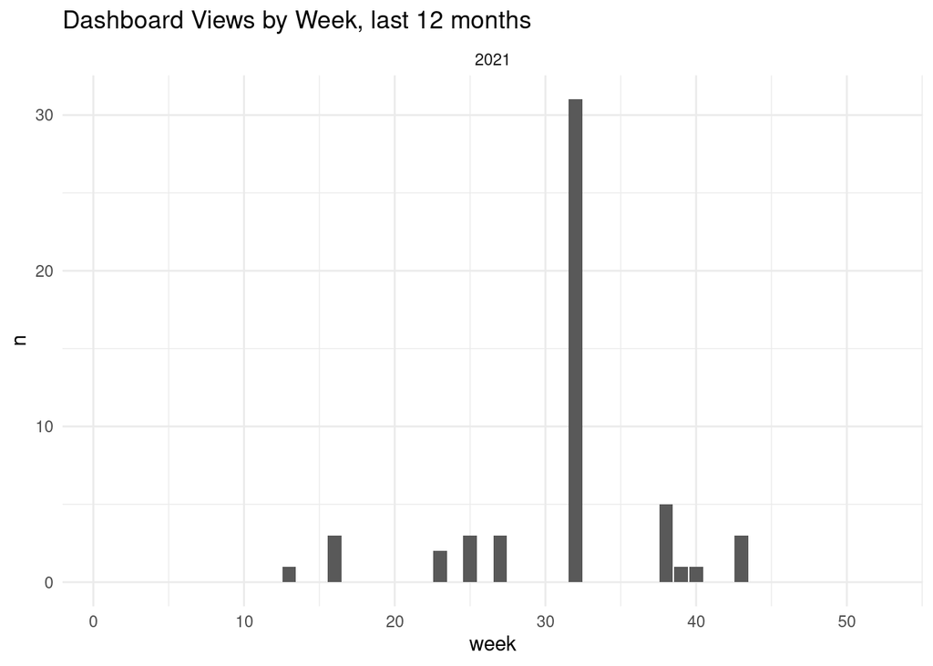

```r
dash_views %>%
  filter(date>floor_date(as.Date(Sys.Date()-months(12)), unit="month")) %>%
  mutate(year=year(date),
         week=as.integer(week(date))) %>%
  count(year,week) %>%
  group_by(year) %>%
  complete(week=seq(from=1,to=52), fill=list(n=0)) %>%
  ggplot() +
  geom_col(aes(x=week,y=n)) +
  facet_wrap(~year, nrow=1) +
  labs(title="Dashboard Views by Week, last 12 months")
```

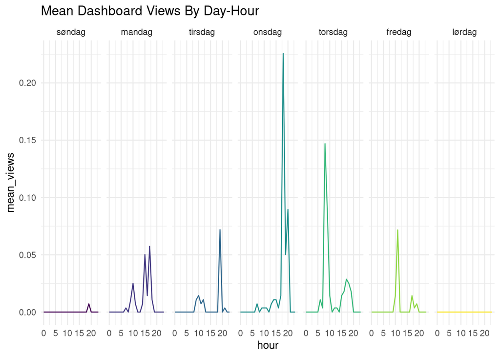

```r
# Dashboard viewers by time of day
dash_tod<-dash_views %>%
  mutate(hour=hour(timestamp)) %>%
  group_by(date, hour) %>%
  summarize(views_date_hour=n()) %>%
  ungroup() %>%
  complete(date=seq.Date(from=min(date), to=max(date),by="days")) %>%
  group_by(date) %>%
  complete(hour=seq(from=0,to=23),fill=list(views_date_hour=0)) %>%
  mutate(day=wday(date, label=TRUE, abbr=FALSE)) %>%
  group_by(day,hour) %>%
  summarize(mean_views=mean(views_date_hour))


dash_tod %>%
  ggplot(aes(x=hour,y=mean_views,color=day)) +
  geom_line() +
  facet_grid(~day) +
  labs(title="Mean Dashboard Views By Day-Hour") +
  theme(legend.position = "none")
```

```r
dash_views %>%
  distinct(username,date) %>%
  count(username, sort=T) %>%
  head(10) %>%
  kable(caption="Most days viewing dashboard(s), by user")
```

Most days viewing dashboard(s), by user

| username | n |
| --- | --- |
| system | 32 |
| admin | 14 |
| analytics | 2 |
| analyticstest | 1 |

# Interpretations + Comments

- Interpretations – Total+comments, total users, count for top 20 users, visualizations with an interpretation/comment

```r
#fetch all interpretations within start/end date
#total interpretations by user
#total visualizations with an interpretation
#average char. length of interpretations

#Get a list of all interpretations and comments
url<-paste0(baseurl,
            "api/interpretations?fields=id,created,text,likes,type,user[id]",
            ",visualization,eventReport,map,eventChart,comments[text,user,created]",
            "&paging=false")
ints<-fromJSON(content(GET(url),type="text", encoding="UTF-8"))

# Skip this if there are no interpretations
if (!is_null(ints$interpretations)){

interpretations<-ints %>%
  pluck("interpretations") %>%
  unnest_longer(comments) %>%
    jsonlite::flatten() %>%
  # select(name,id,type,createdBy,interpretations) %>%
  as_tibble() %>%
  complete() %>%
  select("int_id"=id,type,likes,text,user.id,created,
         comments.text,comments.user.id,comments.created,
         ends_with(".id")) %>%
  unite(col="viz_item_id",visualization.id:eventReport.id,na.rm=T) %>%
  pivot_longer(cols=c(text,comments.text),names_to="text_type",values_to="text") %>%
  filter(!is.na(text)) %>%
  mutate(user=if_else(text_type=="text",user.id,comments.user.id),
         created=if_else(text_type=="text",created,comments.created),
         length=str_length(text)) %>%
  select(everything(),-comments.created,-comments.user.id,-user.id) %>% distinct()

## Selectively fetch the users who have written interpretations
int_users<-paste0(unique(interpretations$user),collapse=",")
url<-paste0(baseurl,"api/users.csv?paging=false&fields=id,name&filter=id:in:[",int_users,"]")
int_users<-read_csv(content(GET(url),type="text", encoding="UTF-8"))

int_table<-interpretations %>%
  mutate(date=as.Date(created)) %>%
  left_join(int_users, by=c("user"="id")) %>%
  group_by(name, user) %>%
  summarize("total interpretations"=n(),
    "unique items with interpretation"=n_distinct(viz_item_id),
    "mean length in characters"=round(mean(length),1),
    "total days with interpretation "=n_distinct(date)) %>%
  arrange(desc(`total interpretations`)) %>%
  head(10) %>%
  kable(caption="Total Interpretations and Comments, Top 10 users")

total_int_comments<-nrow(interpretations)
total_int_users<-length(unique(interpretations$user))


}else{
  print("No Interpretations found")
  total_int_comments<-0
  total_int_users<-0
  int_table<-NULL %>% as_tibble()
  interpretations<-NULL
}

int_table
```

Total Interpretations and Comments, Top 10 users

| name | user | total interpretations | unique items with interpretation | mean length in characters | total days with interpretation |
| --- | --- | --- | --- | --- | --- |
| Tom Wakiki | GOLswS44mh8 | 30 | 19 | 73.4 | 23 |
| John Traore | xE7jOejl9FI | 10 | 4 | 54.6 | 7 |
| John Kamara | N3PZBUlN8vq | 8 | 5 | 210.1 | 5 |
| Didier Konan | I9fMsY4pRKk | 5 | 5 | 142.8 | 3 |
| NA | gEnZri18JsV | 5 | 3 | 221.8 | 2 |
| NA | EZtxytGsq8F | 3 | 2 | 429.7 | 2 |
| Kevin Boateng | OYLGMiazHtW | 1 | 1 | 129.0 | 1 |
| Seydou Keita | Onf73mPD6sL | 1 | 1 | 201.0 | 1 |
| Suleimane Diawara | awtnYWiVEd5 | 1 | 1 | 123.0 | 1 |

Overall, 64 total interpretations and comments were left by 9 users.

# Viz Profiles

Print out the visualization with stats about it.

A usage report for each visualization could look like this, with one page per visualization in the system.

```r
viz_focus<-params$viz_focus

url<-paste0(baseurl, "api/visualizations/",viz_focus,"/data.png")
# resp<-GET(url)

r<-suppressWarnings(GET(url,
    write_disk("test.png", overwrite = TRUE)))
```

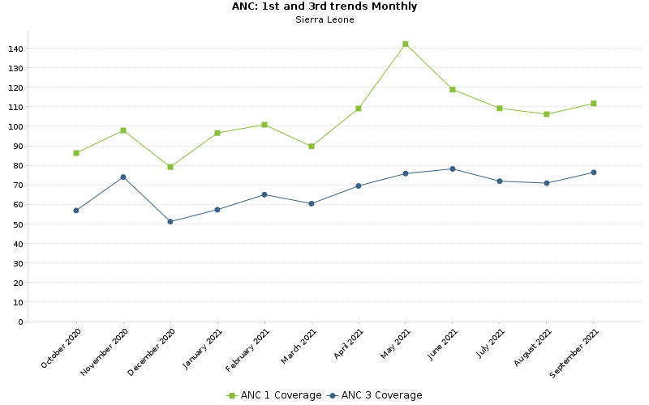

```r
knitr::include_graphics('./test.png')
```

```r
viz_users %>%
  filter(id==viz_focus) %>%
  select(name,type,createdBy.name,created) %>%
  t() %>%
  kable(caption="Visualization Details")
```

Visualization Details

| name | ANC: 1st and 3rd trends Monthly |
| --- | --- |
| type | LINE |
| createdBy.name | Tom Wakiki |
| created | 2012-11-05T09:00:29.592 |

```r
viz_users_dash %>%
    filter(id==viz_focus) %>% select(dash_id) %>%
    left_join(dash_views, by=c("dash_id"="favoriteuid")) %>%
    count(dash_name, sort=T) %>%
    kable(caption="Total Views of dashboards with this Visualization")
```

Total Views of dashboards with this Visualization

| dash_name | n |
| --- | --- |
| Mother and Child Health | 3 |

```r
interpretations %>%
  filter(viz_item_id==viz_focus) %>%
  count(text_type) %>%
  kable(caption="Total interpretations and comments on Viz")
```

Total interpretations and comments on Viz

| text_type | n |
| --- | --- |
| comments.text | 1 |
| text | 1 |

```r
# url<-paste0(baseurl,"api/svg.png")
# resp<-POST(url, body=upload_file("pic_request.txt"), type="application/x-www-form-urlencoded;charset=UTF-8")
#
# httr::content(resp)
# obj<-read_file("pic_request.txt")
# class(obj)
```

# Save

CSV files written to the project’s “outputs” directory

```r
outputs<-list(
  "interpretations"=interpretations,
  "dashboard_views"=dash_views,
  "all_viz_dash_views"=views_dta,
  "visualizations"=viz_users_dash
)

## If folder for outputs doesnt exist create one
if (!dir.exists(here("outputs"))){
  dir.create("outputs")
}

outputs %>%
  names(.) %>%
  map(~ write_csv(outputs[[.]], here("outputs", paste0(., ".csv"))))
```

[output not shown]

[output cut: 9 more lines]

```
## [[4]]
## # A tibble: 427 × 10
##    name      id     int_count obj_name created createdBy.name createdBy.id type
##    <chr>     <chr>      <int> <chr>    <chr>   <chr>          <chr>        <chr>
##  1 Child he… YZzuV…         0 eventRe… 2017-0… Tom Wakiki     GOLswS44mh8  EVEN…
##  2 Child he… sAqSL…         0 eventRe… 2019-0… Tom Wakiki     GOLswS44mh8  EVEN…
##  3 Child he… NTOUv…         0 eventRe… 2017-0… Tom Wakiki     GOLswS44mh8  EVEN…
##  4 Inpatien… aDrb9…         0 eventRe… 2015-0… Tom Wakiki     GOLswS44mh8  EVEN…
##  5 Inpatien… TIuOz…         0 eventRe… 2014-0… John Traore    xE7jOejl9FI  EVEN…
##  6 Inpatien… p8tmW…         0 eventRe… 2017-0… Tom Wakiki     GOLswS44mh8  EVEN…
##  7 Inpatien… fmvL1…         0 eventRe… 2017-0… Tom Wakiki     GOLswS44mh8  EVEN…
##  8 Inpatien… itNBw…         0 eventRe… 2014-0… John Traore    xE7jOejl9FI  EVEN…
##  9 Inpatien… R4wAb…         0 eventRe… 2014-0… John Traore    xE7jOejl9FI  EVEN…
## 10 Inpatien… pLJAn…         0 eventRe… 2014-0… John Traore    xE7jOejl9FI  EVEN…
## # … with 417 more rows, and 2 more variables: dash_name <chr>, dash_id <chr>
```